# Airbnb Data Analysis

Kalsang Sherpa

### Required Packages :

```r
library(tidyverse)
library(tidytext)
library(geomtextpath)
library(wordcloud)
library(RColorBrewer)
library(tm)
```

### Data Importing :

```r
dat <- read_csv("Airbnb_Open_Data.csv")

# view first couple rows
head(dat)
```

| id | NAME | host id | host_identity_verified | host name | neighbourhood group | neighbourhood | lat | long | country | country code | instant_bookable | cancellation_policy | room type | Construction year | price | service fee | minimum nights | number of reviews | last review | reviews per month | review rate number | calculated host listings count | availability 365 | house_rules | license |
| --- | --- | --- | --- | --- | --- | --- | --- | --- | --- | --- | --- | --- | --- | --- | --- | --- | --- | --- | --- | --- | --- | --- | --- | --- | --- |
| 1001254 | Clean & quiet apt home by the park | 80014485718 | unconfirmed | Madaline | Brooklyn | Kensington | 40.64749 | -73.97237 | United States | US | FALSE | strict | Private room | 2020 | $966 | $193 | 10 | 9 | 10/19/2021 | 0.21 | 4 | 6 | 286 | Clean up and treat the home the way you'd like your home to be treated. No smoking. | NA |
| 1002102 | Skylit Midtown Castle | 52335172823 | verified | Jenna | Manhattan | Midtown | 40.75362 | -73.98377 | United States | US | FALSE | moderate | Entire home/apt | 2007 | $142 | $28 | 30 | 45 | 5/21/2022 | 0.38 | 4 | 2 | 228 | Pet friendly but please confirm with me if the pet you are planning on bringing with you is OK. I have a cute and quiet mixed chihuahua. I could accept more guests (for an extra fee) but this also nee… | NA |
| 1002403 | THE VILLAGE OF HARLEM....NEW YORK ! | 78829239556 | NA | Elise | Manhattan | Harlem | 40.80902 | -73.94190 | United States | US | TRUE | flexible | Private room | 2005 | $620 | $124 | 3 | 0 | NA | NA | 5 | 1 | 352 | I encourage you to use my kitchen, cooking and laundry facilities. There is no additional charge to use the washer/dryer in the basement. No smoking, inside or outside. Come home as late as you want. … | NA |
| 1002755 | NA | 85098326012 | unconfirmed | Garry | Brooklyn | Clinton Hill | 40.68514 | -73.95976 | United States | US | TRUE | moderate | Entire home/apt | 2005 | $368 | $74 | 30 | 270 | 7/5/2019 | 4.64 | 4 | 1 | 322 | NA | NA |
| 1003689 | Entire Apt: Spacious Studio/Loft by central park | 92037596077 | verified | Lyndon | Manhattan | East Harlem | 40.79851 | -73.94399 | United States | US | FALSE | moderate | Entire home/apt | 2009 | $204 | $41 | 10 | 9 | 11/19/2018 | 0.10 | 3 | 1 | 289 | Please no smoking in the house, porch or on the property (you can go to the nearby corner). Reasonable quiet after 10:30 pm. Please remove shoes in the house. | NA |
| 1004098 | Large Cozy 1 BR Apartment In Midtown East | 45498551794 | verified | Michelle | Manhattan | Murray Hill | 40.74767 | -73.97500 | United States | US | TRUE | flexible | Entire home/apt | 2013 | $577 | $115 | 3 | 74 | 6/22/2019 | 0.59 | 3 | 1 | 374 | No smoking, please, and no drugs. | NA |

```r
summary(dat)
```

```
##        id               NAME              host id
##  Min.   : 1001254   Length:102599      Min.   :1.236e+08
##  1st Qu.:15085814   Class :character   1st Qu.:2.458e+10
##  Median :29136603   Mode  :character   Median :4.912e+10
##  Mean   :29146235                      Mean   :4.925e+10
##  3rd Qu.:43201198                      3rd Qu.:7.400e+10
##  Max.   :57367417                      Max.   :9.876e+10
##
##  host_identity_verified  host name         neighbourhood group
##  Length:102599          Length:102599      Length:102599
##  Class :character       Class :character   Class :character
##  Mode  :character       Mode  :character   Mode  :character
##
##
##
##
##  neighbourhood           lat             long          country
##  Length:102599      Min.   :40.50   Min.   :-74.25   Length:102599
##  Class :character   1st Qu.:40.69   1st Qu.:-73.98   Class :character
##  Mode  :character   Median :40.72   Median :-73.95   Mode  :character
##                     Mean   :40.73   Mean   :-73.95
##                     3rd Qu.:40.76   3rd Qu.:-73.93
##                     Max.   :40.92   Max.   :-73.71
##                     NA's   :8       NA's   :8
##  country code       instant_bookable cancellation_policy  room type
##  Length:102599      Mode :logical    Length:102599       Length:102599
##  Class :character   FALSE:51474      Class :character    Class :character
##  Mode  :character   TRUE :51020      Mode  :character    Mode  :character
##                     NA's :105
##
##
##
##  Construction year    price           service fee        minimum nights
##  Min.   :2003      Length:102599      Length:102599      Min.   :-1223.000
##  1st Qu.:2007      Class :character   Class :character   1st Qu.:    2.000
##  Median :2012      Mode  :character   Mode  :character   Median :    3.000
##  Mean   :2012                                            Mean   :    8.136
##  3rd Qu.:2017                                            3rd Qu.:    5.000
##  Max.   :2022                                            Max.   : 5645.000
##  NA's   :214                                             NA's   :409
```

[output cut: 9 more lines]

```
##  Min.   :  1.000                Min.   : -10.0   Length:102599
##  1st Qu.:  1.000                1st Qu.:   3.0   Class :character
##  Median :  1.000                Median :  96.0   Mode  :character
##  Mean   :  7.937                Mean   : 141.1
##  3rd Qu.:  2.000                3rd Qu.: 269.0
##  Max.   :332.000                Max.   :3677.0
##  NA's   :319                    NA's   :448
##  license
##  Mode:logical
##  NA's:102599
##
##
##
##
##
```

```r
# Look for missing values
sum(is.na(dat))
```

```
## [1] 190770
```

```r
colSums(is.na(dat))
```

```
##                             id                           NAME
##                              0                            249
##                        host id         host_identity_verified
##                              0                            289
##                      host name            neighbourhood group
##                            406                             29
##                  neighbourhood                            lat
##                             16                              8
##                           long                        country
##                              8                            532
##                   country code               instant_bookable
##                            131                            105
##            cancellation_policy                      room type
##                             76                              0
##              Construction year                          price
##                            214                            247
##                    service fee                 minimum nights
##                            273                            409
##              number of reviews                    last review
##                            183                          15893
##              reviews per month             review rate number
##                          15879                            326
## calculated host listings count               availability 365
##                            319                            448
##                    house_rules                        license
##                          52131                         102599
```

### Data Cleaning :

Some of the column names aren’t consistent. Therefore, in order to follow the same naming rules we changed all column names to lowercase and added an underscore in between words.

```r
# Fix column names to have consistency
header <- colnames(dat)
header
```

```
##  [1] "id"                             "NAME"
##  [3] "host id"                        "host_identity_verified"
##  [5] "host name"                      "neighbourhood group"
##  [7] "neighbourhood"                  "lat"
##  [9] "long"                           "country"
## [11] "country code"                   "instant_bookable"
## [13] "cancellation_policy"            "room type"
## [15] "Construction year"              "price"
## [17] "service fee"                    "minimum nights"
## [19] "number of reviews"              "last review"
## [21] "reviews per month"              "review rate number"
## [23] "calculated host listings count" "availability 365"
## [25] "house_rules"                    "license"
```

```r
header <- tolower(header)
header <- str_replace_all(header, " ", "_")
colnames(dat) <- header # new column names

glimpse(dat)
```

```
## Rows: 102,599
## Columns: 26
## $ id                             <dbl> 1001254, 1002102, 1002403, 1002755, 100…
## $ name                           <chr> "Clean & quiet apt home by the park", "…
## $ host_id                        <dbl> 80014485718, 52335172823, 78829239556, …
## $ host_identity_verified         <chr> "unconfirmed", "verified", NA, "unconfi…
## $ host_name                      <chr> "Madaline", "Jenna", "Elise", "Garry", …
## $ neighbourhood_group            <chr> "Brooklyn", "Manhattan", "Manhattan", "…
## $ neighbourhood                  <chr> "Kensington", "Midtown", "Harlem", "Cli…
## $ lat                            <dbl> 40.64749, 40.75362, 40.80902, 40.68514,…
## $ long                           <dbl> -73.97237, -73.98377, -73.94190, -73.95…
## $ country                        <chr> "United States", "United States", "Unit…
## $ country_code                   <chr> "US", "US", "US", "US", "US", "US", "US…
## $ instant_bookable               <lgl> FALSE, FALSE, TRUE, TRUE, FALSE, TRUE, …
## $ cancellation_policy            <chr> "strict", "moderate", "flexible", "mode…
## $ room_type                      <chr> "Private room", "Entire home/apt", "Pri…
## $ construction_year              <dbl> 2020, 2007, 2005, 2005, 2009, 2013, 201…
## $ price                          <chr> "$966", "$142", "$620", "$368", "$204",…
## $ service_fee                    <chr> "$193", "$28", "$124", "$74", "$41", "$…
## $ minimum_nights                 <dbl> 10, 30, 3, 30, 10, 3, 45, 45, 2, 2, 1, …
## $ number_of_reviews              <dbl> 9, 45, 0, 270, 9, 74, 49, 49, 430, 118,…
## $ last_review                    <chr> "10/19/2021", "5/21/2022", NA, "7/5/201…
## $ reviews_per_month              <dbl> 0.21, 0.38, NA, 4.64, 0.10, 0.59, 0.40,…
## $ review_rate_number             <dbl> 4, 4, 5, 4, 3, 3, 5, 5, 3, 5, 3, 4, 4, …
## $ calculated_host_listings_count <dbl> 6, 2, 1, 1, 1, 1, 1, 1, 1, 1, 4, 1, 1, …
## $ availability_365               <dbl> 286, 228, 352, 322, 289, 374, 224, 219,…
## $ house_rules                    <chr> "Clean up and treat the home the way yo…
## $ license                        <lgl> NA, NA, NA, NA, NA, NA, NA, NA, NA, NA,…
```

Looking at the two columns ‘license’ and ‘house_rules’, we can see that license is completely missing (100% missing data) and house_rules is missing 52,1331 observations (50.81% missing). Drawing the line at 50% we plan to remove anything over 50% missing, since having half the data missing is not favorable for imputation. We also removed ‘country’ and ‘country_code’ since all the data is from only NYC. Lastly, we removed latitude and longitude since our data is all in NYC and doesn’t require those measurements to locate them.

```r
# Remove license and house rules from data set
dat <- dat %>%
  select(-license, -house_rules) %>%
  select(-country, -country_code) %>%
  select(-lat, -long)
```

We drop categorical variables that we would have trouble imputing. We also dropped non-numeric variables such as name and host_name that would not be imputable.

```r
dat <- dat %>%
  drop_na(instant_bookable, name, host_identity_verified, host_name, cancellation_policy)
```

```r
table(dat$neighbourhood_group)
```

```
##
##         Bronx       brookln      Brooklyn     Manhattan        Queens
##          2687             1         41406         43370         13157
## Staten Island
##           943
```

```r
sum(is.na(dat$neighbourhood_group))
```

```
## [1] 18
```

```r
dat <- dat %>%
  # Correct the spelling of neighbourhood groups
  mutate(neighbourhood_group = if_else(neighbourhood_group == "brookln", "Brooklyn", neighbourhood_group))%>%
  mutate(neighbourhood_group = if_else(neighbourhood_group == "manhatan", "Manhattan", neighbourhood_group)) %>%
  # Drop the rows where neighborhood group isn't listed.
  drop_na(neighbourhood_group)

# Remove missing neighbourhood values.
sum(is.na(dat$neighbourhood))
```

```
## [1] 14
```

```r
dat <- drop_na(dat, neighbourhood)
```

Here we first change price and service fee to numerics, then impute the missing values based on the neighborhood averages.

```r
# Change data type of 'price'
dat$price <- gsub(",", "", dat$price)
dat$price <- gsub("\\$", "", dat$price)
dat$price <- as.numeric(dat$price)

# Change data type of 'service_fee'
dat$service_fee <- gsub(",", "", dat$service_fee)
dat$service_fee <- gsub("\\$", "", dat$service_fee)
dat$service_fee <- as.numeric(dat$service_fee)



# Impute missing price with the average price for that neighbourhood group.
dat <- dat %>%
  group_by(neighbourhood_group) %>%
  mutate(price = ifelse(is.na(price), round(mean(price, na.rm = T)), price)) %>%
  # since service fee is dependent on price, we will also change the service fee based on neighbourhood group.
  mutate(service_fee = ifelse(is.na(service_fee), round(mean(service_fee, na.rm = T)), service_fee))
```

Lastly, looking at the remaining missing values, we just removed the remaining ones since we don’t plan on imputing them. By doing this we dropped 16.56% of our data.

```r
colSums(is.na(dat))
```

```
##                             id                           name
##                              0                              0
##                        host_id         host_identity_verified
##                              0                              0
##                      host_name            neighbourhood_group
##                              0                              0
##                  neighbourhood               instant_bookable
##                              0                              0
##            cancellation_policy                      room_type
##                              0                              0
##              construction_year                          price
##                            183                              0
##                    service_fee                 minimum_nights
##                              0                            388
##              number_of_reviews                    last_review
##                            182                          15724
##              reviews_per_month             review_rate_number
##                          15713                            290
## calculated_host_listings_count               availability_365
##                            310                            401
```

```r
pre <- nrow(dat)
# Remove all of the remaining NA's
dat <- na.omit(dat)

print(paste("By dropping the remaining missing values, we have dropped", pre - nrow(dat), "observations.", sep =" "))
```

```
## [1] "By dropping the remaining missing values, we have dropped 16823 observations."
```

### Data Analysis

About 70,282 listings (82.95%) were located in Brooklyn or Manhattan. The highest average price by borough was Queens, coming in at $630.56 a night. When we break down the listings by borough and by room type we can see that the different room types that were listed in each borough.

```r
by_neigh <- dat %>%
  group_by(neighbourhood_group) %>%
  summarise(listings = n(), average_price = mean(price)) %>%
  arrange(desc(listings))
by_neigh
```

| neighbourhood_group | listings | average_price |
| --- | --- | --- |
| Brooklyn | 35154 | 627.5436 |
| Manhattan | 35128 | 623.1754 |
| Queens | 11301 | 630.5613 |
| Bronx | 2310 | 630.2156 |
| Staten Island | 834 | 622.4712 |

```r
neigh_roomtype <- dat %>%
  group_by(neighbourhood_group, room_type) %>%
  summarise(listings = n(), average_price = mean(price))
neigh_roomtype
```

| neighbourhood_group | room_type | listings | average_price |
| --- | --- | --- | --- |
| Bronx | Entire home/apt | 881 | 633.3882 |
| Bronx | Private room | 1339 | 630.6012 |
| Bronx | Shared room | 90 | 593.4222 |
| Brooklyn | Entire home/apt | 18005 | 626.0349 |
| Brooklyn | Hotel room | 8 | 736.1250 |
| Brooklyn | Private room | 16527 | 629.2936 |
| Brooklyn | Shared room | 614 | 623.2622 |
| Manhattan | Entire home/apt | 21008 | 622.6427 |
| Manhattan | Hotel room | 98 | 684.5306 |
| Manhattan | Private room | 13332 | 622.9842 |

[output cut: 8 more lines]

Looking at the density and distribution of listing prices. Price is distributed uniformly.

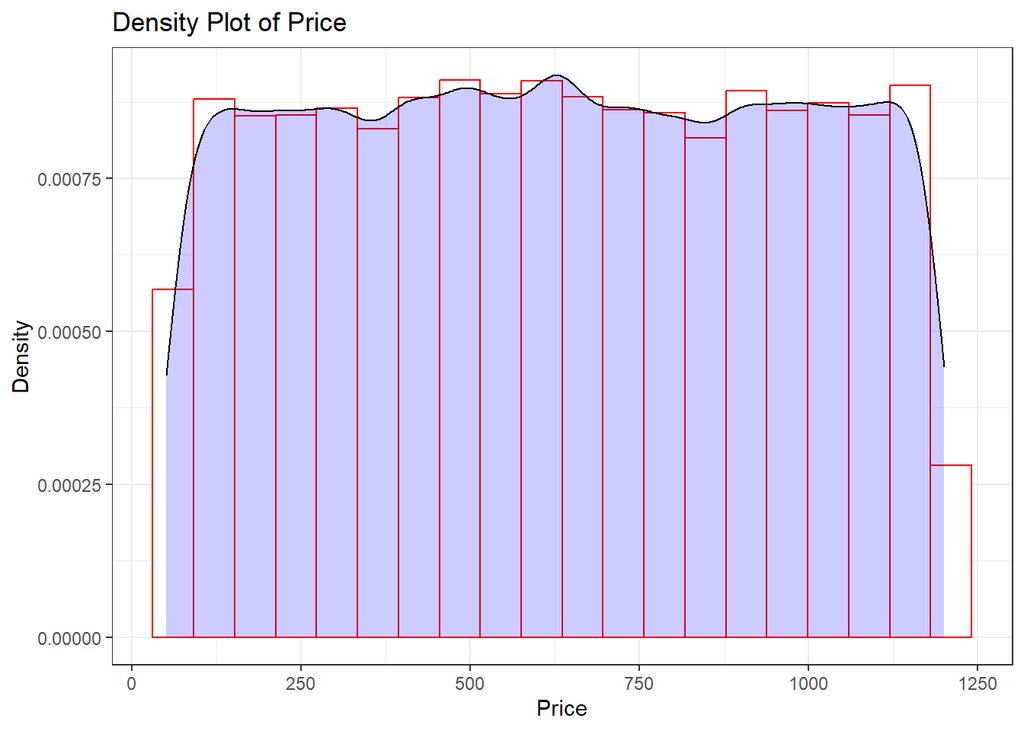

```r
ggplot(dat, aes(x = price)) +
  geom_histogram(aes(y = ..density..), bins = 20, colour = "red", fill = "white") +
  labs(title = "Density Plot of Price",
       x = "Price",
       y = "Density") +
  geom_density(alpha = .2, fill = "blue") +
  theme_bw()
```

Look at the prices of different room types in each borough.

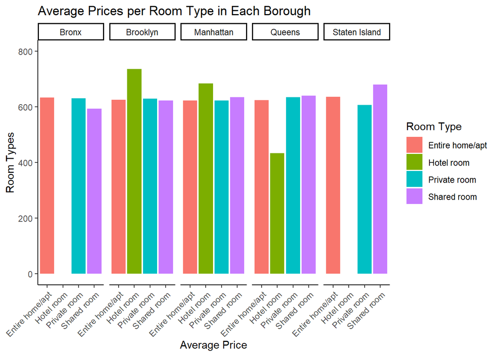

```r
ggplot(neigh_roomtype, aes(x = room_type, y = average_price, group = room_type)) +
  geom_col(aes(stat = "identity", fill = room_type))  +
  scale_y_continuous(limits = c(0, 800)) +
  labs(title = "Average Prices per Room Type in Each Borough",
       x = "Average Price",
       y = "Room Types",
       fill = "Room Type") +
  theme_classic() +
  theme(axis.text.x = element_text(angle = 45, hjust = 1, vjust = 1)) +
  facet_grid(. ~ neighbourhood_group)
```

Check the distribution of review ratings.

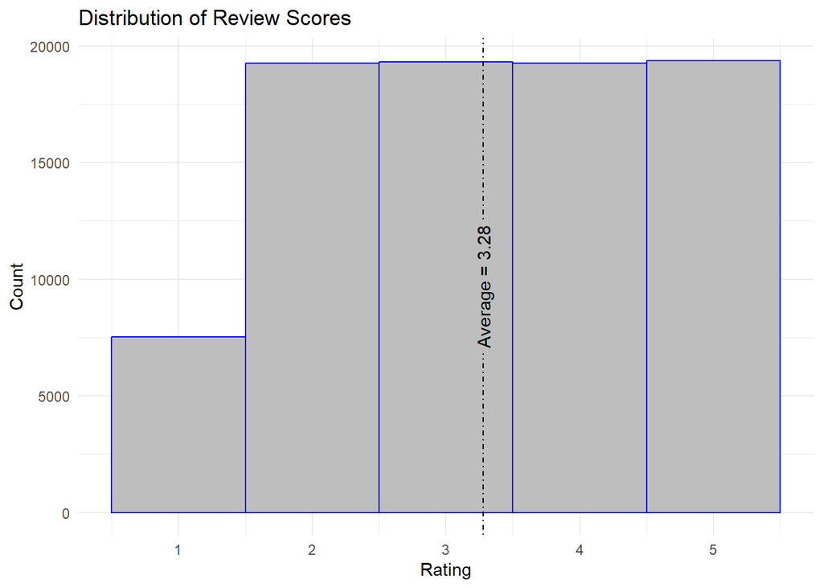

```r
avg_rating <- round(mean(dat$review_rate_number), digits = 2)
ggplot(dat, aes(x = review_rate_number)) +
  geom_histogram(binwidth = 1, color = "blue", fill = "grey") +
  labs(title = "Distribution of Review Scores",
       x = "Rating",
       y = "Count") +
  geom_textvline(xintercept = avg_rating, linetype = "dotdash", label = paste("Average = ", avg_rating, sep = "")) +
  theme_minimal()
```

Visualize the top ten average review ratings based on neighbourhoods. In order to qualify, neighbourhood must have at least 50 listings.

```r
# Find top ten neighborhoods in terms of reviews.
top_ten <- dat %>%
  group_by(neighbourhood_group, neighbourhood) %>%
  summarise(listings = n(), avg_rating = mean(review_rate_number)) %>%
  arrange(desc(avg_rating)) %>%
  # Set threshold to at least 50 listings.
  filter(listings > 50)
```

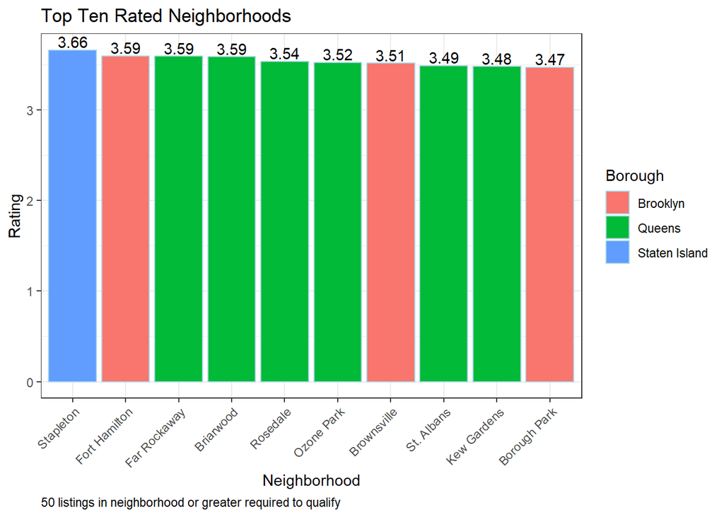

```r
# get the first 10.
top_ten <- top_ten[1:10,]
top_ten$neighbourhood <- factor(top_ten$neighbourhood, levels = top_ten$neighbourhood[order(top_ten$avg_rating, decreasing = TRUE)])


ggplot(top_ten, aes(x = neighbourhood, y = avg_rating, group = neighbourhood_group)) +
  geom_col(aes(stat = "identity", fill = top_ten$neighbourhood_group), color = "lightblue") +
  labs(title = "Top Ten Rated Neighborhoods",
       x = "Neighborhood",
       y = "Rating",
       fill = "Borough",
       caption = "50 listings in neighborhood or greater required to qualify") +
  geom_text(label = round(top_ten$avg_rating, digits = 2), position = position_dodge(0.9), vjust = -0.2) +
  theme_bw() +
  theme(axis.text.x = element_text(angle = 45, hjust = 1, vjust = 1),
        plot.caption = element_text(hjust = 0))
```

Look at the differences in reviews between different cancellation policies.

```r
prop.table(table(dat$cancellation_policy))
```

```
##
##  flexible  moderate    strict
## 0.3320547 0.3350526 0.3328927
```

```r
# Check to see review by different cancellation policies.
by_policy <- dat %>%
  group_by(cancellation_policy) %>%
  summarise(average_review = mean(review_rate_number))
by_policy
```

| cancellation_policy | average_review |
| --- | --- |
| flexible | 3.281119 |
| moderate | 3.281351 |
| strict | 3.278036 |

View average review ratings by borough.

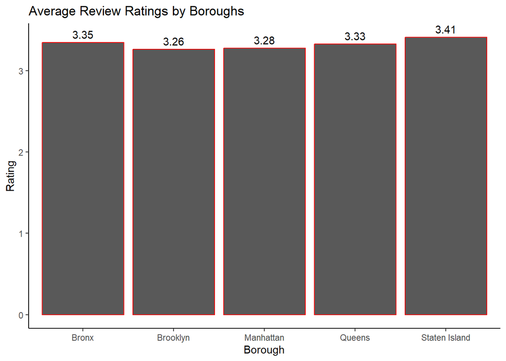

```r
# View review by boroughs.
borough_review <- dat %>%
  group_by(neighbourhood_group) %>%
  summarise(avg_review = mean(review_rate_number))

ggplot(borough_review, aes(x = neighbourhood_group, y = avg_review)) +
  geom_col(aes(stat = "identity"), color = "red") +
  geom_text(label = round(borough_review$avg_review, digits = 2), position = position_dodge(0.9), vjust = -0.5) +
  labs(title = "Average Review Ratings by Boroughs", x = "Borough", y = "Rating") +
  theme_classic()
```

```r
# Get 4 and 5 star reviews.
highreviews.dat <- dat %>%
  filter(review_rate_number > 4 | review_rate_number >5)
highreviews.dat <- tibble(highreviews.dat[,2])

txt <- highreviews.dat$name
corp.dat <- Corpus(VectorSource(txt))

# Clean up the text.
corp.dat <- corp.dat %>%
  tm_map(removePunctuation) %>%
  tm_map(removeNumbers) %>%
  tm_map(stripWhitespace) %>%
  tm_map(removeWords, stopwords("english"))

tdm.dat <- TermDocumentMatrix(corp.dat)
matrix <- as.matrix(tdm.dat)
results <- sort(rowSums(matrix), decreasing = TRUE)

df.dat <- data.frame(word = names(results), freq = results)


# Store only adjectives
df.dat <- df.dat %>%
  left_join(parts_of_speech) %>%
  filter(pos %in% "Adjective")
head(df.dat)
```

|  | word | freq | pos |
| --- | --- | --- | --- |
| 1 | private | 3048 | Adjective |
| 2 | cozy | 2125 | Adjective |
| 3 | apt | 1740 | Adjective |
| 4 | spacious | 1432 | Adjective |
| 5 | east | 1121 | Adjective |
| 6 | sunny | 1030 | Adjective |

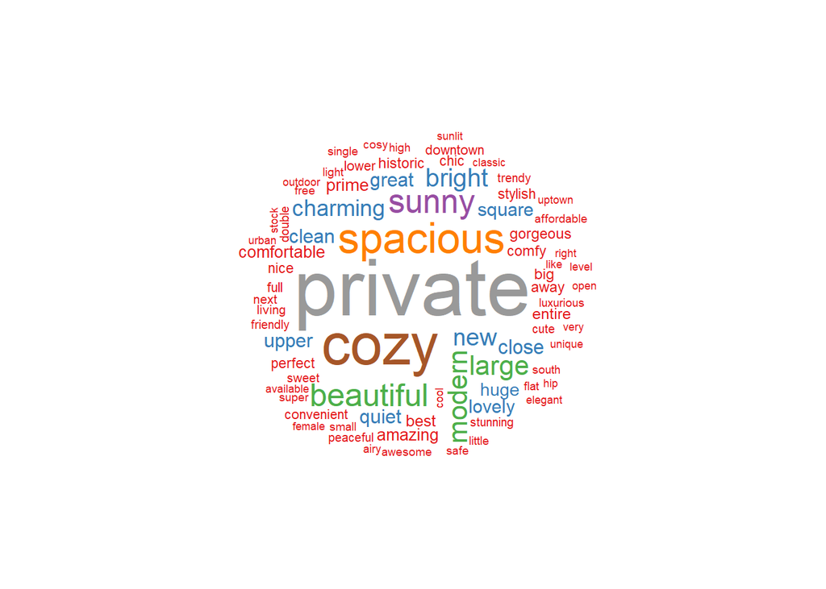

```r
# Manually remove some words
df.dat <- df.dat[c(-3, -5, -8, -11, -15, -16),]

# Create word cloud
set.seed(3005)
wordcloud(words = df.dat$word, freq = df.dat$freq, min.freq = 50, random.order = FALSE, colors = brewer.pal(9, 'Set1'))
```

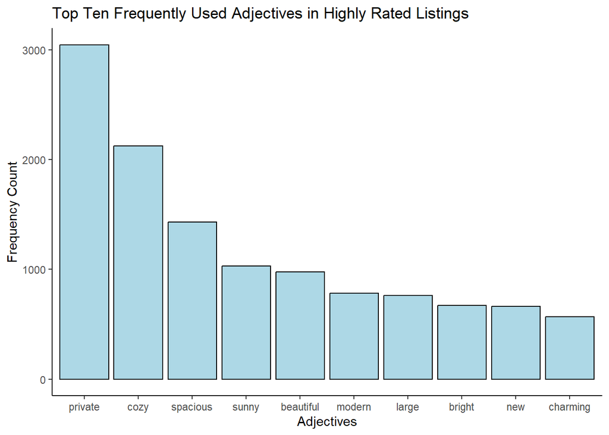

```r
top_ten <- df.dat[1:10,]
top_ten$word <- factor(top_ten$word, levels = top_ten$word[order(top_ten$freq, decreasing = TRUE)])
ggplot(top_ten, aes(x = word, y = freq)) +
  geom_col(aes(stat = "identity"), fill = "lightblue", color = "black") +
  labs(title = "Top Ten Frequently Used Adjectives in Highly Rated Listings",
       x = "Adjectives",
       y = "Frequency Count") +
  theme_classic()
```